# Virginia Election Project

Author

Samiha

# Data Wrangling & Analysis

First we’ll begin by cleaning up and joining two data sets containing info on the 2020 national election results, as well as the VA governor race.

Data available here: https://historical.elections.virginia.gov/elections/view/144567/

```r
prez_2020 <- read_csv("processed_data/va_2020_prez_cleaned.csv")
```

Taking a first look at the data

```r
head(prez_2020)
```

```
# A tibble: 6 × 4
  locality         biden trump total_votes_2021_prez
  <chr>            <dbl> <dbl>                 <dbl>
1 Accomack County   7578  9172                 16962
2 Albemarle County 42466 20804                 64657
3 Alexandria City  66240 14544                 82508
4 Alleghany County  2243  5859                  8203
5 Amelia County     2411  5390                  7893
6 Amherst County    5672 11041                 17005
```

Calculating percentage of the vote

```r
prez_2020 %>%
  mutate(
    biden_pct = biden/total_votes_2021_prez
  )
```

```
# A tibble: 134 × 5
   locality           biden trump total_votes_2021_prez biden_pct
   <chr>              <dbl> <dbl>                 <dbl>     <dbl>
 1 Accomack County     7578  9172                 16962     0.447
 2 Albemarle County   42466 20804                 64657     0.657
 3 Alexandria City    66240 14544                 82508     0.803
 4 Alleghany County    2243  5859                  8203     0.273
 5 Amelia County       2411  5390                  7893     0.305
 6 Amherst County      5672 11041                 17005     0.334
 7 Appomattox County   2418  6702                  9268     0.261
 8 Arlington County  105344 22318                130699     0.806
 9 Augusta County     10840 30714                 42278     0.256
10 Bath County          646  1834                  2501     0.258
# … with 124 more rows
```

Now let’s do some rounding and move that decimal point

```r
prez_2020 %>%
  mutate(
    biden_pct = janitor::round_half_up(biden / total_votes_2021_prez * 100, 1)
  )
```

```
# A tibble: 134 × 5
   locality           biden trump total_votes_2021_prez biden_pct
   <chr>              <dbl> <dbl>                 <dbl>     <dbl>
 1 Accomack County     7578  9172                 16962      44.7
 2 Albemarle County   42466 20804                 64657      65.7
 3 Alexandria City    66240 14544                 82508      80.3
 4 Alleghany County    2243  5859                  8203      27.3
 5 Amelia County       2411  5390                  7893      30.5
 6 Amherst County      5672 11041                 17005      33.4
 7 Appomattox County   2418  6702                  9268      26.1
 8 Arlington County  105344 22318                130699      80.6
 9 Augusta County     10840 30714                 42278      25.6
10 Bath County          646  1834                  2501      25.8
# … with 124 more rows
```

Calculating the percentage of the total votes Biden and Trump respectively recieved

```r
prez_2020 <- prez_2020 %>%
  mutate(
    biden_pct = janitor::round_half_up(biden / total_votes_2021_prez * 100, 2),
    trump_pct = janitor::round_half_up(trump / total_votes_2021_prez * 100, 2)
  )

head(prez_2020)
```

```
# A tibble: 6 × 6
  locality         biden trump total_votes_2021_prez biden_pct trump_pct
  <chr>            <dbl> <dbl>                 <dbl>     <dbl>     <dbl>
1 Accomack County   7578  9172                 16962      44.7      54.1
2 Albemarle County 42466 20804                 64657      65.7      32.2
3 Alexandria City  66240 14544                 82508      80.3      17.6
4 Alleghany County  2243  5859                  8203      27.3      71.4
5 Amelia County     2411  5390                  7893      30.6      68.3
6 Amherst County    5672 11041                 17005      33.4      64.9
```

Data now available from the state here: https://historical.elections.virginia.gov/elections/view/147466.

```r
jsonfile <- "raw_data/va_gov_json_archived.json"

#using jsonlite package function fromJSON()
this.content <- fromJSON(jsonfile)

#dataframe from just the 6 content
content_df <- as.data.frame(this.content[[6]])
```

Where are candidates themselves? They are “nested” inside. We’ll use `unnest()`to expand things.

```r
#unnest
results <- content_df %>%
  unnest(cols = Candidates)

head(results)
```

```
# A tibble: 6 × 9
  Locali…¹ $Loca…² Preci…³ Preci…⁴ LastM…⁵ Ballo…⁶ Ballo…⁷ Votes Perce…⁸ Polit…⁹
  <chr>    <chr>     <int>   <int> <chr>   <chr>     <int> <int> <chr>   <chr>
1 ACCOMAC… 001          19      19 2021-1… Glenn …  1   e0  7878 61.08%  Republ…
2 ACCOMAC… 001          19      19 2021-1… Terry …  2   e0  4948 38.37%  Democr…
3 ACCOMAC… 001          19      19 2021-1… Prince…  3   e0    67 0.52%   Libera…
4 ACCOMAC… 001          19      19 2021-1… Write …  2.15e9     4 0.03%   Write-…
5 ALBEMAR… 003          33      33 2021-1… Glenn …  1   e0 19141 37.21%  Republ…
6 ALBEMAR… 003          33      33 2021-1… Terry …  2   e0 31919 62.05%  Democr…
# … with abbreviated variable names ¹Locality$LocalityName, ²$LocalityCode,
#   ³PrecinctsReporting, ⁴PrecinctsParticipating, ⁵LastModified, ⁶BallotName,
#   ⁷BallotOrder, ⁸Percentage, ⁹PoliticalParty
```

Unnest again on locality

```r
results <- results %>%
  unnest(cols = Locality)

head(results)
```

```
# A tibble: 6 × 10
  Locali…¹ Local…² Preci…³ Preci…⁴ LastM…⁵ Ballo…⁶ Ballo…⁷ Votes Perce…⁸ Polit…⁹
  <chr>    <chr>     <int>   <int> <chr>   <chr>     <int> <int> <chr>   <chr>
1 ACCOMAC… 001          19      19 2021-1… Glenn …  1   e0  7878 61.08%  Republ…
2 ACCOMAC… 001          19      19 2021-1… Terry …  2   e0  4948 38.37%  Democr…
3 ACCOMAC… 001          19      19 2021-1… Prince…  3   e0    67 0.52%   Libera…
4 ACCOMAC… 001          19      19 2021-1… Write …  2.15e9     4 0.03%   Write-…
5 ALBEMAR… 003          33      33 2021-1… Glenn …  1   e0 19141 37.21%  Republ…
6 ALBEMAR… 003          33      33 2021-1… Terry …  2   e0 31919 62.05%  Democr…
# … with abbreviated variable names ¹LocalityName, ²LocalityCode,
#   ³PrecinctsReporting, ⁴PrecinctsParticipating, ⁵LastModified, ⁶BallotName,
#   ⁷BallotOrder, ⁸Percentage, ⁹PoliticalParty
```

Cleaning up the columns

```r
gov_2021 <- results %>%
  clean_names() %>%
  select(-precincts_reporting,
         -precincts_participating,
         -last_modified,
         -ballot_order)

head(gov_2021)
```

```
# A tibble: 6 × 6
  locality_name    locality_code ballot_name          votes percentage politic…¹
  <chr>            <chr>         <chr>                <int> <chr>      <chr>
1 ACCOMACK COUNTY  001           Glenn A. Youngkin     7878 61.08%     Republic…
2 ACCOMACK COUNTY  001           Terry R. McAuliffe    4948 38.37%     Democrat…
3 ACCOMACK COUNTY  001           Princess L. Blanding    67 0.52%      Liberati…
4 ACCOMACK COUNTY  001           Write In                 4 0.03%      Write-In
5 ALBEMARLE COUNTY 003           Glenn A. Youngkin    19141 37.21%     Republic…
6 ALBEMARLE COUNTY 003           Terry R. McAuliffe   31919 62.05%     Democrat…
# … with abbreviated variable name ¹political_party
```

Reshaping the data so that it’s easier to use

```r
gov_2021 <- gov_2021 %>%
  filter(ballot_name %in% c("Glenn A. Youngkin", "Terry R. McAuliffe")) %>%
  select(-locality_code,
         -political_party)

gov_2021
```

```
# A tibble: 266 × 4
   locality_name    ballot_name        votes percentage
   <chr>            <chr>              <int> <chr>
 1 ACCOMACK COUNTY  Glenn A. Youngkin   7878 61.08%
 2 ACCOMACK COUNTY  Terry R. McAuliffe  4948 38.37%
 3 ALBEMARLE COUNTY Glenn A. Youngkin  19141 37.21%
 4 ALBEMARLE COUNTY Terry R. McAuliffe 31919 62.05%
 5 ALEXANDRIA CITY  Glenn A. Youngkin  14013 24.02%
 6 ALEXANDRIA CITY  Terry R. McAuliffe 43866 75.20%
 7 ALLEGHANY COUNTY Glenn A. Youngkin   4530 74.52%
 8 ALLEGHANY COUNTY Terry R. McAuliffe  1518 24.97%
 9 AMELIA COUNTY    Glenn A. Youngkin   4720 74.19%
10 AMELIA COUNTY    Terry R. McAuliffe  1617 25.42%
# … with 256 more rows
```

```r
gov_2021_wide <- gov_2021 %>%
  pivot_wider(names_from = ballot_name, values_from = c(votes, percentage))

gov_2021_wide
```

```
# A tibble: 133 × 5
   locality_name     `votes_Glenn A. Youngkin` votes_Terry R. …¹ perce…² perce…³
   <chr>                                 <int>             <int> <chr>   <chr>
 1 ACCOMACK COUNTY                        7878              4948 61.08%  38.37%
 2 ALBEMARLE COUNTY                      19141             31919 37.21%  62.05%
 3 ALEXANDRIA CITY                       14013             43866 24.02%  75.20%
 4 ALLEGHANY COUNTY                       4530              1518 74.52%  24.97%
 5 AMELIA COUNTY                          4720              1617 74.19%  25.42%
 6 AMHERST COUNTY                         9731              3897 71.00%  28.43%
 7 APPOMATTOX COUNTY                      5971              1438 80.26%  19.33%
 8 ARLINGTON COUNTY                      21548             73013 22.63%  76.67%
 9 AUGUSTA COUNTY                        26196              7231 77.93%  21.51%
10 BATH COUNTY                            1539               396 79.04%  20.34%
# … with 123 more rows, and abbreviated variable names
#   ¹`votes_Terry R. McAuliffe`, ²`percentage_Glenn A. Youngkin`,
#   ³`percentage_Terry R. McAuliffe`
```

```r
gov_2021_wide <- gov_2021_wide %>%
  clean_names()

head(gov_2021_wide)
```

```
# A tibble: 6 × 5
  locality_name    votes_glenn_a_youngkin votes_terry_r_mc_aul…¹ perce…² perce…³
  <chr>                             <int>                  <int> <chr>   <chr>
1 ACCOMACK COUNTY                    7878                   4948 61.08%  38.37%
2 ALBEMARLE COUNTY                  19141                  31919 37.21%  62.05%
3 ALEXANDRIA CITY                   14013                  43866 24.02%  75.20%
4 ALLEGHANY COUNTY                   4530                   1518 74.52%  24.97%
5 AMELIA COUNTY                      4720                   1617 74.19%  25.42%
6 AMHERST COUNTY                     9731                   3897 71.00%  28.43%
# … with abbreviated variable names ¹votes_terry_r_mc_auliffe,
#   ²percentage_glenn_a_youngkin, ³percentage_terry_r_mc_auliffe
```

```r
gov_2021_wide <- gov_2021_wide %>%
  rename(
    youngkin = votes_glenn_a_youngkin,
    mcauliffe = votes_terry_r_mc_auliffe,
    pct_youngkin = percentage_glenn_a_youngkin,
    pct_mcauliffe = percentage_terry_r_mc_auliffe
  )

head(gov_2021_wide)
```

```
# A tibble: 6 × 5
  locality_name    youngkin mcauliffe pct_youngkin pct_mcauliffe
  <chr>               <int>     <int> <chr>        <chr>
1 ACCOMACK COUNTY      7878      4948 61.08%       38.37%
2 ALBEMARLE COUNTY    19141     31919 37.21%       62.05%
3 ALEXANDRIA CITY     14013     43866 24.02%       75.20%
4 ALLEGHANY COUNTY     4530      1518 74.52%       24.97%
5 AMELIA COUNTY        4720      1617 74.19%       25.42%
6 AMHERST COUNTY       9731      3897 71.00%       28.43%
```

```r
gov_2021_wide <- gov_2021_wide %>%
  mutate(
    pct_youngkin = readr::parse_number(pct_youngkin),
    pct_mcauliffe = readr::parse_number(pct_mcauliffe)
  )

head(gov_2021_wide)
```

```
# A tibble: 6 × 5
  locality_name    youngkin mcauliffe pct_youngkin pct_mcauliffe
  <chr>               <int>     <int>        <dbl>         <dbl>
1 ACCOMACK COUNTY      7878      4948         61.1          38.4
2 ALBEMARLE COUNTY    19141     31919         37.2          62.0
3 ALEXANDRIA CITY     14013     43866         24.0          75.2
4 ALLEGHANY COUNTY     4530      1518         74.5          25.0
5 AMELIA COUNTY        4720      1617         74.2          25.4
6 AMHERST COUNTY       9731      3897         71            28.4
```

Perfect. Problem solved.

## Joining the Two Data Sets

```r
gov_2021_wide
```

```
# A tibble: 133 × 5
   locality_name     youngkin mcauliffe pct_youngkin pct_mcauliffe
   <chr>                <int>     <int>        <dbl>         <dbl>
 1 ACCOMACK COUNTY       7878      4948         61.1          38.4
 2 ALBEMARLE COUNTY     19141     31919         37.2          62.0
 3 ALEXANDRIA CITY      14013     43866         24.0          75.2
 4 ALLEGHANY COUNTY      4530      1518         74.5          25.0
 5 AMELIA COUNTY         4720      1617         74.2          25.4
 6 AMHERST COUNTY        9731      3897         71            28.4
 7 APPOMATTOX COUNTY     5971      1438         80.3          19.3
 8 ARLINGTON COUNTY     21548     73013         22.6          76.7
 9 AUGUSTA COUNTY       26196      7231         77.9          21.5
10 BATH COUNTY           1539       396         79.0          20.3
# … with 123 more rows
```

```r
prez_2020
```

```
# A tibble: 134 × 6
   locality           biden trump total_votes_2021_prez biden_pct trump_pct
   <chr>              <dbl> <dbl>                 <dbl>     <dbl>     <dbl>
 1 Accomack County     7578  9172                 16962      44.7      54.1
 2 Albemarle County   42466 20804                 64657      65.7      32.2
 3 Alexandria City    66240 14544                 82508      80.3      17.6
 4 Alleghany County    2243  5859                  8203      27.3      71.4
 5 Amelia County       2411  5390                  7893      30.6      68.3
 6 Amherst County      5672 11041                 17005      33.4      64.9
 7 Appomattox County   2418  6702                  9268      26.1      72.3
 8 Arlington County  105344 22318                130699      80.6      17.1
 9 Augusta County     10840 30714                 42278      25.6      72.6
10 Bath County          646  1834                  2501      25.8      73.3
# … with 124 more rows
```

Cleaning up the data sets to get them ready for the join

```r
prez_2020 <- prez_2020 %>%
  mutate(
    locality = str_to_upper(locality)
  ) %>%
  select(-total_votes_2021_prez)

prez_2020
```

```
# A tibble: 134 × 5
   locality           biden trump biden_pct trump_pct
   <chr>              <dbl> <dbl>     <dbl>     <dbl>
 1 ACCOMACK COUNTY     7578  9172      44.7      54.1
 2 ALBEMARLE COUNTY   42466 20804      65.7      32.2
 3 ALEXANDRIA CITY    66240 14544      80.3      17.6
 4 ALLEGHANY COUNTY    2243  5859      27.3      71.4
 5 AMELIA COUNTY       2411  5390      30.6      68.3
 6 AMHERST COUNTY      5672 11041      33.4      64.9
 7 APPOMATTOX COUNTY   2418  6702      26.1      72.3
 8 ARLINGTON COUNTY  105344 22318      80.6      17.1
 9 AUGUSTA COUNTY     10840 30714      25.6      72.6
10 BATH COUNTY          646  1834      25.8      73.3
# … with 124 more rows
```

```r
anti_join(prez_2020, gov_2021_wide, by = c("locality" = "locality_name"))
```

```
# A tibble: 2 × 5
  locality                biden   trump biden_pct trump_pct
  <chr>                   <dbl>   <dbl>     <dbl>     <dbl>
1 KING AND QUEEN COUNTY    1590    2450      38.6      59.5
2 TOTALS                2413568 1962430      54.1      44
```

```r
anti_join(gov_2021_wide, prez_2020, by = c("locality_name" = "locality"))
```

```
# A tibble: 1 × 5
  locality_name       youngkin mcauliffe pct_youngkin pct_mcauliffe
  <chr>                  <int>     <int>        <dbl>         <dbl>
1 KING & QUEEN COUNTY     2112      1130         64.8          34.6
```

```r
prez_2020 <- prez_2020 %>%
  filter(locality != "TOTALS") %>%
  mutate(
    locality = str_replace(locality, "KING AND QUEEN", "KING & QUEEN")
  )
```

Now joining

```r
joined_vacomparison <- inner_join(prez_2020, gov_2021_wide, by = c("locality" = "locality_name"))

head(joined_vacomparison)
```

```
# A tibble: 6 × 9
  locality         biden trump biden_pct trump…¹ young…² mcaul…³ pct_y…⁴ pct_m…⁵
  <chr>            <dbl> <dbl>     <dbl>   <dbl>   <int>   <int>   <dbl>   <dbl>
1 ACCOMACK COUNTY   7578  9172      44.7    54.1    7878    4948    61.1    38.4
2 ALBEMARLE COUNTY 42466 20804      65.7    32.2   19141   31919    37.2    62.0
3 ALEXANDRIA CITY  66240 14544      80.3    17.6   14013   43866    24.0    75.2
4 ALLEGHANY COUNTY  2243  5859      27.3    71.4    4530    1518    74.5    25.0
5 AMELIA COUNTY     2411  5390      30.6    68.3    4720    1617    74.2    25.4
6 AMHERST COUNTY    5672 11041      33.4    64.9    9731    3897    71      28.4
# … with abbreviated variable names ¹trump_pct, ²youngkin, ³mcauliffe,
#   ⁴pct_youngkin, ⁵pct_mcauliffe
```

```r
#save results to file for next step
saveRDS(joined_vacomparison, here("processed_data", "joined_vacomparison.rds"))
write_csv(joined_vacomparison, here("processed_data", "joined_vacomparison.csv"))
```

```r
joined_vacomparison %>%
  mutate(
    mc_overperform = pct_mcauliffe - biden_pct,
    mc_overperform_5 <- if_else(mc_overperform < -5, "Yes", "No")
  )
```

```
# A tibble: 133 × 11
   locality  biden trump biden…¹ trump…² young…³ mcaul…⁴ pct_y…⁵ pct_m…⁶ mc_ov…⁷
   <chr>     <dbl> <dbl>   <dbl>   <dbl>   <int>   <int>   <dbl>   <dbl>   <dbl>
 1 ACCOMAC…   7578  9172    44.7    54.1    7878    4948    61.1    38.4   -6.31
 2 ALBEMAR…  42466 20804    65.7    32.2   19141   31919    37.2    62.0   -3.63
 3 ALEXAND…  66240 14544    80.3    17.6   14013   43866    24.0    75.2   -5.08
 4 ALLEGHA…   2243  5859    27.3    71.4    4530    1518    74.5    25.0   -2.37
 5 AMELIA …   2411  5390    30.6    68.3    4720    1617    74.2    25.4   -5.13
 6 AMHERST…   5672 11041    33.4    64.9    9731    3897    71      28.4   -4.92
 7 APPOMAT…   2418  6702    26.1    72.3    5971    1438    80.3    19.3   -6.76
 8 ARLINGT… 105344 22318    80.6    17.1   21548   73013    22.6    76.7   -3.93
 9 AUGUSTA…  10840 30714    25.6    72.6   26196    7231    77.9    21.5   -4.13
10 BATH CO…    646  1834    25.8    73.3    1539     396    79.0    20.3   -5.49
# … with 123 more rows, 1 more variable: `mc_overperform_5 <- ...` <chr>, and
#   abbreviated variable names ¹biden_pct, ²trump_pct, ³youngkin, ⁴mcauliffe,
#   ⁵pct_youngkin, ⁶pct_mcauliffe, ⁷mc_overperform
```

```r
saveRDS(joined_vacomparison, here("processed_data", "joined_vacomparison.rds"))
write_csv(joined_vacomparison, here("processed_data", "joined_vacomparison.csv"))
```

```r
head(joined_vacomparison)
```

```
# A tibble: 6 × 9
  locality         biden trump biden_pct trump…¹ young…² mcaul…³ pct_y…⁴ pct_m…⁵
  <chr>            <dbl> <dbl>     <dbl>   <dbl>   <int>   <int>   <dbl>   <dbl>
1 ACCOMACK COUNTY   7578  9172      44.7    54.1    7878    4948    61.1    38.4
2 ALBEMARLE COUNTY 42466 20804      65.7    32.2   19141   31919    37.2    62.0
3 ALEXANDRIA CITY  66240 14544      80.3    17.6   14013   43866    24.0    75.2
4 ALLEGHANY COUNTY  2243  5859      27.3    71.4    4530    1518    74.5    25.0
5 AMELIA COUNTY     2411  5390      30.6    68.3    4720    1617    74.2    25.4
6 AMHERST COUNTY    5672 11041      33.4    64.9    9731    3897    71      28.4
# … with abbreviated variable names ¹trump_pct, ²youngkin, ³mcauliffe,
#   ⁴pct_youngkin, ⁵pct_mcauliffe
```

First, need to join the data set with a shapefile in order to produce a map

```r
va_count_geo <- tigris::counties(state = "VA", resolution = "20m", cb = TRUE)
va_count_geo$NAMELSAD <- toupper(va_count_geo$NAMELSAD)

va_elect_sf <- va_count_geo %>%
  left_join(. , joined_vacomparison, by=c("NAMELSAD"="locality"))
```

```r
mypopup <- glue::glue("<strong>{va_elect_sf$NAME}</strong><br />
                      Biden Pct: {va_elect_sf$biden_pct}<br />") %>%
  lapply(htmltools::HTML)
```

Now I’ll create each map and clean them up to get them ready for comparison

```r
biden_map = mapview(va_elect_sf, zcol = "biden_pct",
                    col.regions = RColorBrewer::brewer.pal(9, "Blues"),
                    alpha.regions = 1,
                    popup = mypopup)
```

```r
mcauliffe_map = mapview(va_elect_sf, zcol = "pct_mcauliffe",
                        col.regions = RColorBrewer::brewer.pal(9, "Blues"),
                        alpha.regions = 1,
                        popup = mypopup)
```

```r
trump_map = mapview(va_elect_sf, zcol = "trump_pct",
                        col.regions = RColorBrewer::brewer.pal(9, "Reds"),
                        alpha.regions = 1,
                        popup = mypopup)
```

```r
youngkin_map = mapview(va_elect_sf, zcol = "pct_youngkin",
                        col.regions = RColorBrewer::brewer.pal(9, "Reds"),
                        alpha.regions = 1,
                        popup = mypopup)
```

Here is a map

```r
sync(youngkin_map, mcauliffe_map)
```

[interactive chart not shown]

```r
sync(trump_map, biden_map)
```

[interactive chart not shown]

We can also see how Biden and McAuliffe compare to each other by district

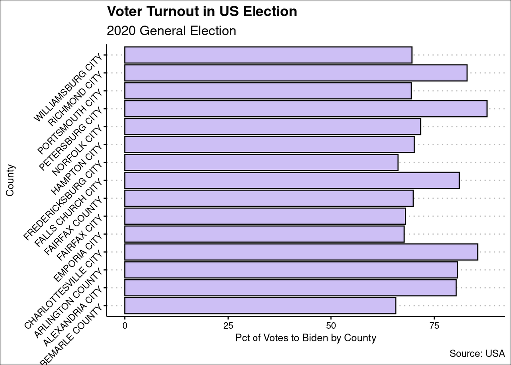

```r
joined_vacomparison %>%
  arrange(desc(biden_pct)) %>%
  head(15) %>%
  ggplot(aes(x = locality, y = biden_pct)) +
  geom_col(color = "black", fill = "#CDBFF5") +
  coord_flip() +
  scale_y_continuous(name = "Pct of Votes to Biden by County") +
  scale_x_discrete(name = "County") +
  theme_clean() +
  labs(title = "Voter Turnout in US Election",
       subtitle = "2020 General Election",
       caption = "Source: USA") +
  theme(axis.text.y = element_text(angle = 45))
```

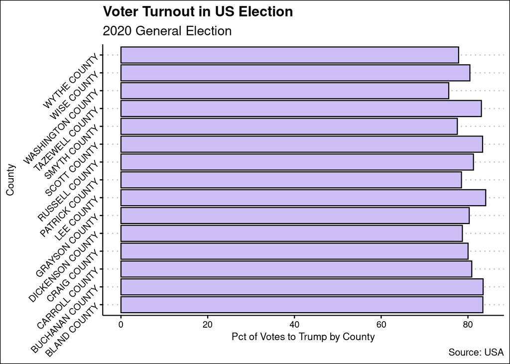

```r
joined_vacomparison %>%
  arrange(desc(trump_pct)) %>%
  head(15) %>%
  ggplot(aes(x = locality, y = trump_pct)) +
  geom_col(color = "black", fill = "#CDBFF5") +
  coord_flip() +
  scale_y_continuous(name = "Pct of Votes to Trump by County") +
  scale_x_discrete(name = "County") +
  theme_clean() +
  labs(title = "Voter Turnout in US Election",
       subtitle = "2020 General Election",
       caption = "Source: USA") +
  theme(axis.text.y = element_text(angle = 45))
```

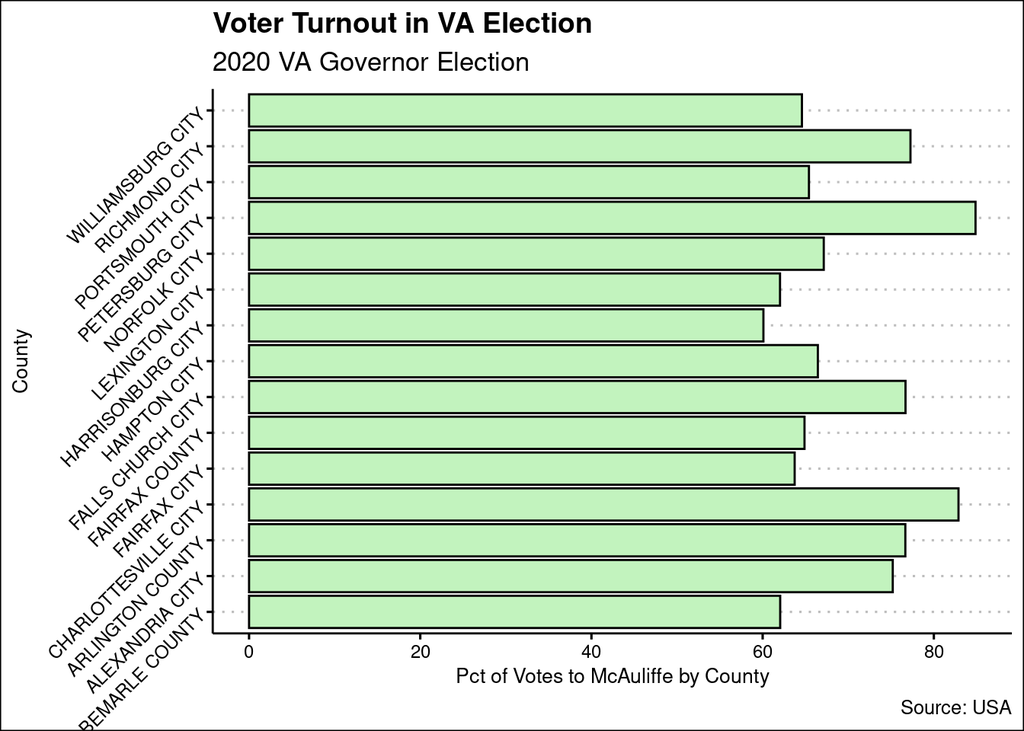

```r
joined_vacomparison %>%
  arrange(desc(pct_mcauliffe)) %>%
  head(15) %>%
  ggplot(aes(x = locality, y = pct_mcauliffe)) +
  geom_col(color = "black", fill = "#C2F3BE") +
  coord_flip() +
  scale_y_continuous(name = "Pct of Votes to McAuliffe by County") +
  scale_x_discrete(name = "County") +
  theme_clean() +
  labs(title = "Voter Turnout in VA Election",
       subtitle = "2020 VA Governor Election",
       caption = "Source: USA") +
  theme(axis.text.y = element_text(angle = 45))
```

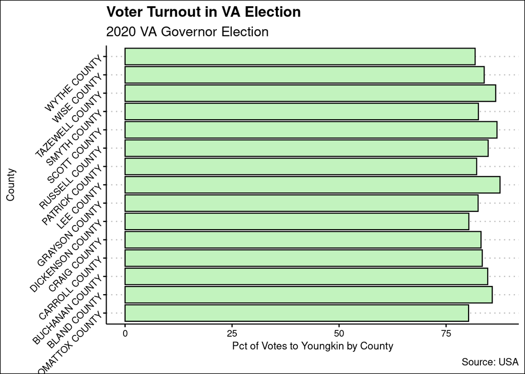

```r
joined_vacomparison %>%
  arrange(desc(pct_youngkin)) %>%
  head(15) %>%
  ggplot(aes(x = locality, y = pct_youngkin)) +
  geom_col(color = "black", fill = "#C2F3BE") +
  coord_flip() +
  scale_y_continuous(name = "Pct of Votes to Youngkin by County") +
  scale_x_discrete(name = "County") +
  theme_clean() +
  labs(title = "Voter Turnout in VA Election",
       subtitle = "2020 VA Governor Election",
       caption = "Source: USA") +
  theme(axis.text.y = element_text(angle = 45))
```